# LavaRand: Seeds of Randomness for Security

Kara VanAllen, Claire Tepesch, Michelle Wong

4/28/2019

## Blog Post Based on [This](https://blog.cloudflare.com/lavarand-in-production-the-nitty-gritty-technical-details/) Article

Randomness in different fields can mean different things. For example, in statistics, random might just mean that if you flip a coin, you don’t know whether or not it’s going to be heads or tails. However, for cryptography, unpredictability is also important because computers can detect patterns very well, so to achieve security, we have to find ways of generating that. Randomness is essential because you then create something that an attacker won’t be able to replicate. This creates the key question for cryptographers: How does a machine generate randomness?

One way to create random numbers is to let a computer rely on phenomena outside of the device itself. In the case of LavaRand, that phenomenon is lava lamps. This idea actually was first invented in 1996 by Landon Noll, a mathematician and cryptographer working on computer security. He created LavaRand, a patented system that made use of Lava Lites in order to generate random numbers, under the patent name “Method for seeding a pseudo-random number generator with a cryptographic hash of a digitization of a chaotic system.” In the process, lava lamps provide a natural source of entropy; the flow of lava is very unpredictable, so entropy of the lamps is incredibly high. It creates way more entropy than is even necessary!

So how does CloudFlare use this technology, exactly? Lava Rand is used as a system that provides an additional entropy source to Cloudflare’s existing production machines. A video feed of a wall of lava lamps is used to generate entropy that is made available to the production “Fleet.” Mixing multiple sources of randomness together in the system’s entropy pool is a common approach to address security issues, with the idea that as long as some off the sources remain uncompromised, the system remains secure. A Camera is pointed at the wall, obtains entropy from visual input from the lava lamps and random noise from the photoreceptors. Server that connects to the camera, server has its own entropy system, and the output of thee entropy system is mixed with the entropy from the camera to produce new entropy feed. So if we have resolution of 100x100 pixels, and an attacker can guess the value of any pixel of the image to within one bit of the precision, then total entropy amount produced by the image is 100x100x3 = 30,000 bits.

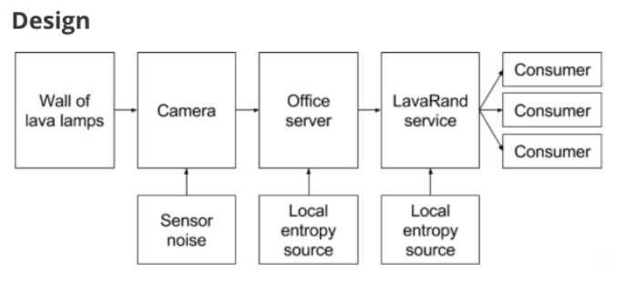

Figure 1. Diagram explaining the CloudFlare system using lava lamps as a source of entropy.

Once we have the random numbers, the purpose for cryptography is simple. Take, for example, the “One-Time Pad” system. The key need to using this demonstrably difficult to crack system is to efficiently generate keys that are at least at long as the message we want to send. Thus, we use cryptographic pseudorandom generators to determine those keys. LavaRand is one system that can be used to create random numbers that can be used as keys in cryptographic systems. In the field of cryptography, the generation of pseudorandom numbers with cryptographically secure pseudorandom number generators, or CSPRNGs for short, uses three different methods to achieve pseudorandomness. Some methods uses ciphers or hashes, some use mathematical problems that are thought to be hard, and some use special purpose designs. LavaRand uses the latter method, a special purpose design that makes use of entropy.

LavaRand’s solution to creating random numbers for cryptography certainly has an artistic flare, but it does beg the question: is a method of pseudorandom number generation this rigorous even necessary? Despite the fact that LavaRand’s system’s complexity indicates that there is a challenge in finding random numbers that is not quite the case at the moment. Even CloudFare mentions in their explanation of LavaRand that their hope is that they never truly need to use it, and can continue to rely primarily on the entropy generated by their production machines. However, things change very rapidly in the field of cryptography, and new developments are always on the horizon. Methods that we previously thought were secure, even including the cryptographic hash method that the NSA used for their secure systems, have been cracked.

Additionally, even LavaRand’s system does have some potential flaws. An attacker with code running in the office could potentially modify the output of the entropy feed generated by that server it a way that would be fatal: running code on the production service which produces the final entropy feed. However, as long as an attacker is unable to predict the output of the other feeds, then they won’t be able to predict the output of the entropy feed generated by this system. It is undoubtedly a secure system that satisfies the objective. Overall, because we can only rely on the belief that systems are hard to crack and we can’t rely on physical proof, creating rigorous systems using entropy are the best guarantee of security that we have.

The LavaRand system is an aesthetic and inspiring way of using entropy in a design to create one of the most successful and reliably secure systems for creating cryptographically secure pseudorandom number generators.

#### Team Contributions

Michelle: Conducted initial research into topic and definition of unpredictability in cryptography; Kara: Created final blog post using RMarkdown, managing presentation flow; Claire: Synthesizing and creating final blog post content, relating topic to course material.